# A Twitter Data Analysis of the COVID-19 Impact in One’s Life 🦠

#### Association Rules

Our team not only interested in the sentiments that would be transmitted through the Twitter from the front line workers, but also interested in the words that the front line workers would speak, in specific in the context of mentioning themselves. Therefore, in other to perform the association rules, our team utilized the first data set of 993 observations were the Twitter users clearly stated that they were front line workers. The following graphs are ordered respectively by the 5, 10 and 20 words with the most expressive lifts. Our team utilized as threshold `0.01 of support and 0.5 of confidence that resulted in more than 200000 association rules`

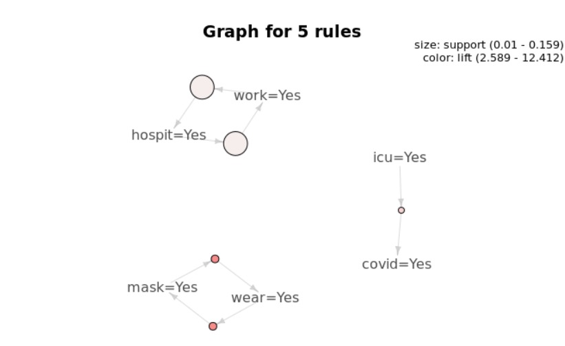

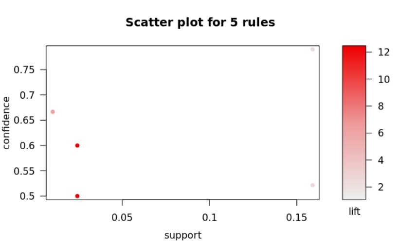

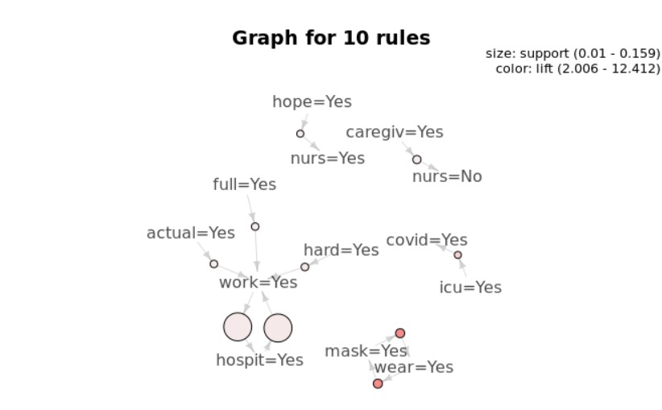

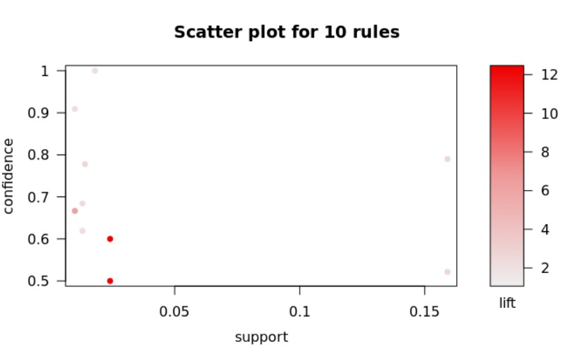

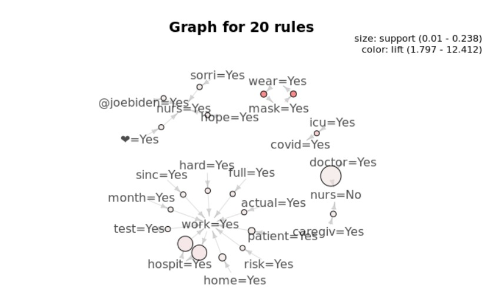

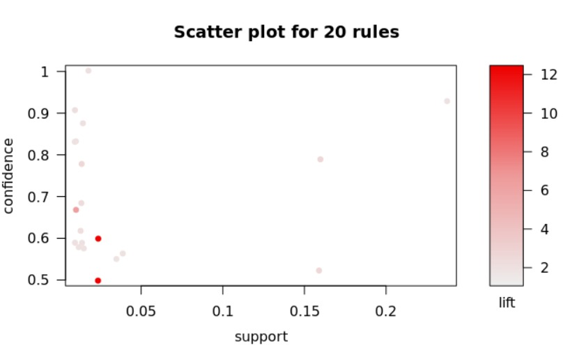

## 💉 Covid-19 vaccine

### What are the expectations of the Covid-19 vaccine?

Also, we conducted a different type of analysis (“Vaccine Analysis 2”) where we found the tweets that were Semantic Differential Adjectives (Opposites from each Other) - Semantic Differential Adjectives:

- Excited vs Scared
- Happy vs mad
- Good vs Bad
- Safe vs Dangerous
- Hopeful vs Hesitant

#### Vaccine Analysis 1

In the following graphs, you can see visualizations for “Vaccine Analysis 1”. You can see the sentences that include these words in their tweets.

[figure not shown]

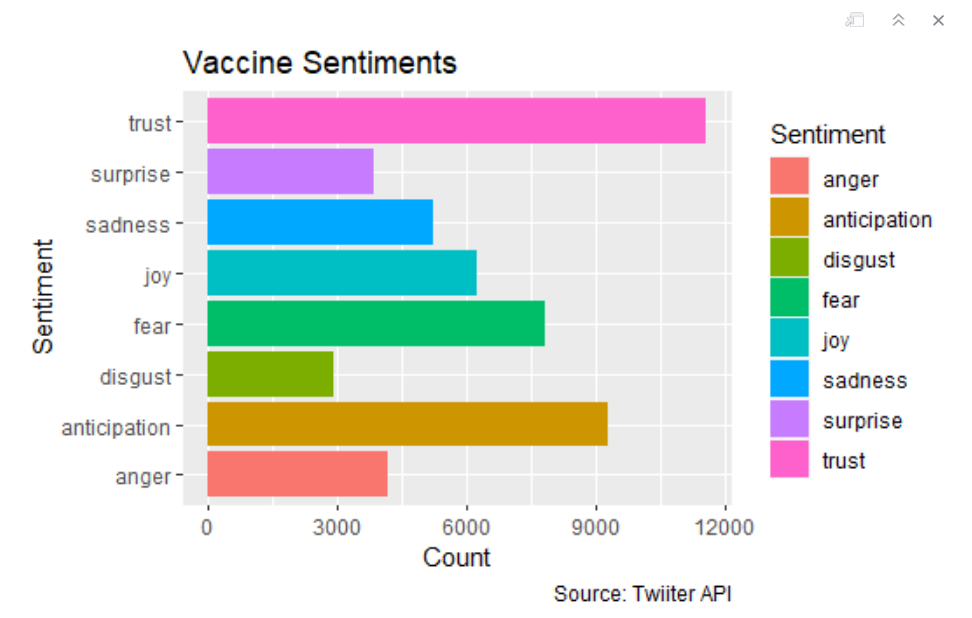

#### Vaccine Analysis 2

In this visualizations, you’ll see how the semantic differentials appear and compare to each other on the tweets.

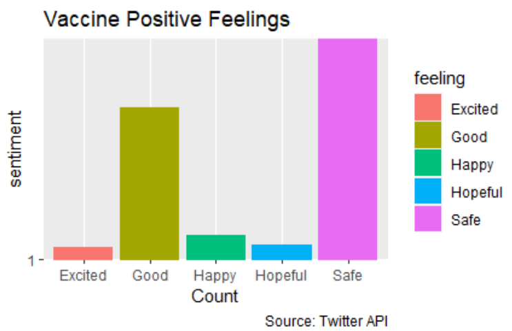

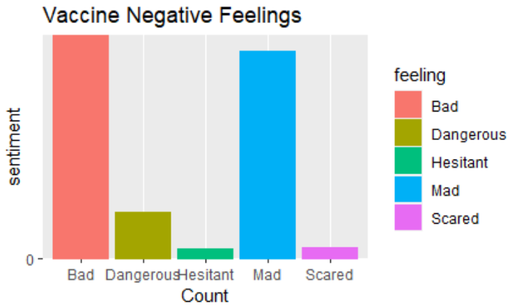

### Negative vs Positive Feelings

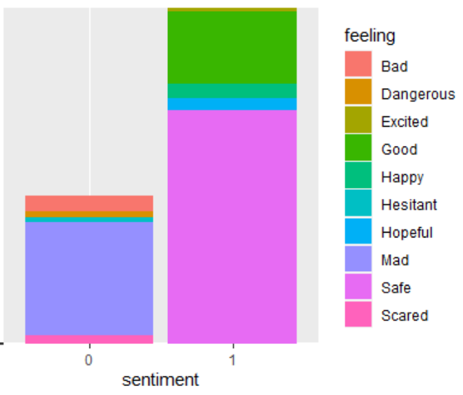

#### Naive Bayes Model

- We conducted a Naive Bayes Model to see if given the user feelings, will the tweet have a positive negative sentiment?
- The accuracy of this model was 0.5

#### Non Linear Regression (Loess Method)

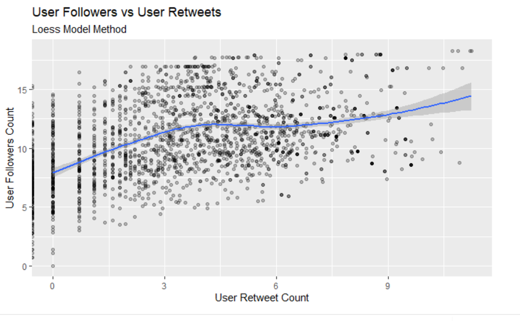

# References

[1] R Core Team (2020). R: A language and environment for statistical computing. R Foundation for Statistical Computing, Vienna, Austria. URL https://www.R-project.org/.

[2] RStudio Team (2020). RStudio: Integrated Development for R. RStudio, PBC, Boston, MA URL http://www.rstudio.com/.

[3] Software Freedom Conservancy, Inc., 2020. [Online]. Available: https://git-scm.com/

[4] GitHub, Inc., 2020. [Online]. Available: https://github.com/

[5] Wickham et al., (2019). Welcome to the tidyverse. Journal of Open Source Software, 4(43), 1686, https://doi.org/10.21105/joss.01686

[6] Taiyun Wei and Viliam Simko (2017). R package “corrplot”: Visualization of a Correlation Matrix (Version 0.84). Available from https://github.com/taiyun/corrplot

[7] Jarek Tuszynski (2020). caTools: Tools: Moving Window Statistics, GIF, Base64, ROC AUC, etc. R package version 1.18.0. https://CRAN.R-project.org/package=caTools

[8] Max Kuhn (2020). caret: Classification and Regression Training. R package version 6.0-86. https://CRAN.R-project.org/package=caret

[9] Hyndman R, Athanasopoulos G, Bergmeir C, Caceres G, Chhay L, O’Hara-Wild M, Petropoulos F, Razbash S, Wang E, Yasmeen F (2020). *forecast: Forecasting functions for time series and linear models*. R package version 8.13, <URL: https://pkg.robjhyndman.com/forecast/>.

[10] Hahsler M, Buchta C, Gruen B, Hornik K (2020). arules: Mining Association Rules and Frequent Itemsets. R package version 1.6-6, https://CRAN.R-project.org/package=arules.

[11] Michael Hahsler (2019). arulesViz: Visualizing Association Rules and Frequent Itemsets. R package version 1.3-3. https://CRAN.R-project.org/package=arulesViz

[12] Grolemund G, Wickham H (2011). “Dates and Times Made Easy with lubridate.” Journal of Statistical Software, 40(3), 1–25. https://www.jstatsoft.org/v40/i03/.

[13] Hadley Wickham (2019). stringr: Simple, Consistent Wrappers for Common String Operations. R Package version 1.4.0 https://cran.r-project.org/web/packages/stringr/index.html

[14] Feinerer I, Hornik K (2020). tm: Text Mining Package. R package version 0.7-8, https://CRAN.R-project.org/package=tm.

[15] Benoit K, Watanabe K, Wang H, Nulty P, Obeng A, Müller S, Matsuo A (2018). “quanteda: An R package for the quantitative analysis of textual data.” Journal of Open Source Software, 3(30), 774. doi: 10.21105/joss.00774, https://quanteda.io.

[16] Wickham H (2007). “Reshaping Data with the reshape Package.” Journal of Statistical Software, 21(12), 1–20. http://www.jstatsoft.org/v21/i12/.

[17] Blei, David M. and Ng, Andrew and Jordan, Michael (2003). Latent Dirichlet allocation. Journal of Machine Learning Research, 2003. https://cran.r-project.org/web/packages/lda/index.html.

[18] Jockers ML (2015). Syuzhet: Extract Sentiment and Plot Arcs from Text. https://github.com/mjockers/syuzhet.

[19] Dawei Lang, Guan-tin Chien (2018). Wordcloud2: Create Word Cloud. https://cran.r-project.org/web/packages/wordcloud2/index.html.

[20] Erich Neuwirth (2014). RColorBrewer: ColorBrewer Palettes. https://cran.r-project.org/web/packages/RColorBrewer/index.html

[21] Hothorn T, Hornik K, Zeileis A (2006). “Unbiased Recursive Partitioning: A Conditional Inference Framework.” Journal of Computational and Graphical Statistics, 15(3), 651–674. https://cran.r-project.org/web/packages/party/index.html

[22] Terry Therneau (2017). rpart: Recursive Partitioning and Regression Trees. https://cran.r-project.org/package=rpart

[23] Stephen Milborrow (2017). rpart.plot: Plot ‘rpart’ Models: An Enhanced Version of ‘plot.rpart’. https://cran.r-project.org/package=rpart.plot

[24] David Meyer (2020) e1071: Misc Functions of the Department of Statistics, Probability Theory Group (Formerly: E1071), TU Wien

[25] Kearney MW (2019). “rtweet: Collecting and analyzing Twitter data.” Journal of Open Source Software, 4(42), 1829. doi: 10.21105/joss.01829, R package version 0.7.0, https://joss.theoj.org/papers/10.21105/joss.01829.

[26] Jeroen Ooms (2020) RMySQL: Database Interface and ‘MySQL’ Driver for R. Version 0.10.20. https://cran.r-project.org/package=RMySQL

[27] Jim Heste (2020) odbc: Connect to ODBC Compatible Databases (using the DBI Interface) https://cran.r-project.org/package=odbc

[28] Kirill Mülle (2019) DBI: R Database Interface. https://cran.r-project.org/package=DBI

[29] https://www.sciencedirect.com/science/article/pii/S156849462030692X

[30] https://www.ncbi.nlm.nih.gov/pmc/articles/PMC7591875/

## Technical/Code

Greatings from the Team!

If you are here, probably you read through the entire report

Thank you for your time and we hope you enjoyed our report!

If you would like to uderstand how all the analysis were done the R scripts are available at:

https://github.com/EnzoNMigliano/A_Twitter_Data_Analysis_of_the_COVID19_Impact_in_ones_life

**Connection to the AWS**

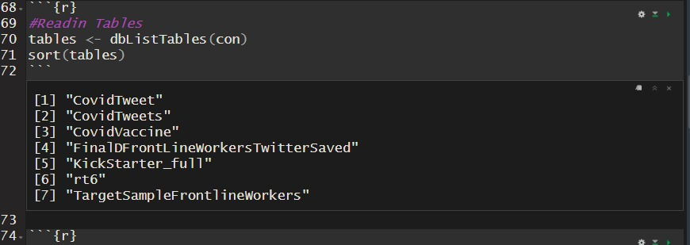

# “Keep calm and be P<0.05”